# 02-revisao

## 1. Números complexos

### Definições:

Seja um número complexo $z= a+jb$, os elementos $a$ e $b$ correspondem às suas partes real e imaginária, respectivamente; e $j^2 = -1$.

```python
# Importação de módulo matemático
import numpy as np

# Daclarando um numero complexo z
a = 2 # Parte real
b = 3 # Parte imaginária
z = complex(a,b) # compondo partes real e imaginária

# Exibição
print( 'Número complexo z: ', z )
print( 'Parte real de z: ', z.real )
print( 'Parte imaginária de z: ', z.imag )
```

```
Número complexo z:  (2+3j)
Parte real de z:  2.0
Parte imaginária de z:  3.0
```

### Representação no plano complexo

O número complexo $z$ também pode ser representado por um vetor $(a,b)$ sendo, portanto, associado a pontos de um plano (denominado *plano complexo Z*)

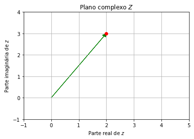

```python
# Impotação de módulo para exibição de gráficos
import matplotlib.pyplot as plt

# Função para traçar gráfico em 2D
plt.plot( z.real, z.imag, 'or' )
plt.arrow(0, 0, z.real, z.imag, head_width=0.15, head_length=0.15, length_includes_head = True, fc='g', ec='g');

# Formatação
plt.grid( True )
plt.axis( [ -1 , 5, -1, 4 ] )
plt.xlabel( 'Parte real de $z$' )
plt.ylabel( 'Parte imaginária de $z$' )
plt.title( 'Plano complexo $Z$' )

# Exibir gráfico
plt.show()
```

### Forma cartesiana

$z = a + j b$

### Forma polar

$\begin{align*} z &= \| z\|\exp\{j\theta\}\\ &= \|z\|e^{j\theta} \end{align*}$

### Conversão de uma representação em outra

#### Da forma retangular para polar

- $\|z\| = \sqrt{a^2 + b^2}$
- $\theta = \arctan (b/a)$

#### Da forma polar para retangular

- $a = \|z\|\cos \theta$
- $b = \|z\|\sin \theta$

### Fórmula de Euler

$e^{j\theta} = \cos \theta + j\sin \theta$

*Demonstração:*

$\begin{align*} z &= \cos \theta + j \sin \theta\\ dz &= (-\sin \theta + j \cos \theta) d\theta\\ &= j(\cos \theta +j\sin \theta) d\theta\\ &= jzd\theta\\ \int \frac{dz}{z} &= \int jd\theta\\ \ln z &= j\theta\\ z &= e^{j\theta} \end{align*}$

## 2. Álgebra Linear

### Vetor

$\mathbf x = \begin{pmatrix} x_1 & x_2 &\cdots & x_N \end{pmatrix}^T$

- $x_i\in \mathbb C$ (escalares)
- $N\in \mathbb Z$
- $\mathbf x \in \mathbb C^N$

### Operações

#### Soma de dois vetores

$\mathbf x = \begin{pmatrix} x_1 & x_2 &\cdots & x_N \end{pmatrix}^T$, $\quad\mathbf y = \begin{pmatrix} y_1 & y_2 &\cdots & y_N \end{pmatrix}^T$

$\mathbf x+\mathbf y = \begin{pmatrix} x_1+y_1 & x_2+y_2 &\cdots & x_N+y_N \end{pmatrix}^T$

#### Multiplicação por escalar

$\mathbf x = \begin{pmatrix} x_1 & x_2 &\cdots & x_N \end{pmatrix}^T$,

$\alpha \mathbf x = \begin{pmatrix} \alpha x_1 & \alpha x_2 &\cdots & \alpha x_N \end{pmatrix}^T$,

#### Produto escalar

$\mathbf x = \begin{pmatrix} x_1 & x_2 &\cdots & x_N \end{pmatrix}^T$, $\quad\mathbf y = \begin{pmatrix} y_1 & y_2 &\cdots & y_N \end{pmatrix}^T$

$\begin{align*} <\mathbf x, \mathbf y> &= x_1y_1^* + x_2y_2^* + \cdots + x_Ny_N^*\\ &= \mathbf x^T \mathbf y^* \end{align*}$

Para o caso em que os vetores são reais

$\begin{equation*} <\mathbf x, \mathbf y> = \|\mathbf x\|\|\mathbf y\|\cos \phi \end{equation*}$

onde $\|\mathbf x\|^2= x_1^2 + x_2^2 + \cdots + x_N^2$

Qual a interpretação geométrica de $<\mathbf x, \mathbf y>$?

### Espaço vetorial de Hilbert

Vetores: $\mathbf x \in \mathbb R^\infty$ ou seja $\mathbf x = \begin{pmatrix} x_1 & x_2 &\cdots \end{pmatrix}^T$

Além disso: $\|\mathbf x \|^2 < \infty$

### Bases

Seja $V$ um sub-espaço vetorial, se qualquer vetor de $V$ puder ser expresso pela combinação linear de um conjunto de vetores linearmente independentes $\{\mathbf v_1, \mathbf v_2, \cdots, \mathbf v_N \}$, esse conjunto de vetores forma uma base para o sub-espaço $V$.

#### Bases ortogonais

Se os vetores $\{\mathbf v_1, \mathbf v_2, \cdots, \mathbf v_N \}$ além de linearmente independentes obedecerem à propriedade

$\begin{equation*} <\mathbf v_i, \mathbf v_j> = \begin{cases} k, & i=j\\ 0, & i\neq j\end{cases} \end{equation*}$

diz-se que a base é ortogonal.

Um caso de interesse ainda mais particular é quando $k = 1$ (bases ortonormais).

### Algoritmo de Gram-Schmidt

- Como transformar uma base qualquer em uma base ortonormal.
- Solução de mínimos quadrados e reconstrução truncada da série transformada de Fourier

## 3. Série de Fourier

### Função periódica

$f(t) = f(t+T) \quad \forall t$, onde $t\in \mathbb R$

### Análise

$a_k = \frac{1}{T}\int\limits_T f(t) e^{-jk\Omega_0 t} dt$, $k \in \mathbb Z$

### Síntese

$f(t) = \sum\limits_{k=-\infty}^\infty a_k e^{jk\Omega_0 t}$

### Reconstrução truncada

$f(t) = \sum\limits_{k=-M}^M a_k e^{jk\Omega_0 t}$